# Assignment_2

#### Student Name: Rajas Bakshi

#### Programme title: Master of Science in Data Science CWS07

#### Programme code: CWS07

#### Module title: Statistics for Data Science

## Introducton

Wine is a fortified grape juice-based alcoholic beverage. The ethanol and carbon dioxide in the wine is created by yeast by consuming the sugar from the grapes. Wines are available in various styles, of which most popular are sparkling wines, White wine, Red wine, Rosè. Although it was once considered a luxury drink now, it is widely enjoyed by a range of consumers (Cortez et al., 2009). Evidence can be found that wine was in production for thousands of years. Moreover, wine also has considerable importance in some religions. Red wine is associated with blood in Egyptians, Romans, Christians, Greek, and many more connections of the wine can be seen in ancient culture (“Wine,” 2021). To support the increasing market, wine sellers have heavy investments in producing as well as selling wines. The taste of the wine is an essential feature that consumer considers while buying the bottle of wine. However, the taste is one of the least understood human senses. Wine tasting is often seen as a difficult skill to learn or to teach because,wine tasting is in the form of sensation, which is a challenging skill to pass on. Also, often there is a difference between the perspective of two people performing the test. Thus, the classification of wine is a tedious task (Cortez et al., 2009). In this study uses data analysis and machine learning to classify the data by taste preference.

## Dataset

A unique product, vinho verde from Portugal, has been chosen for the study. This wine holds about 15% of the total wine market share of Portugal (CVRVV, n.d.). In this study, we analyze the data on red wine. The data has been captured by iLabs. It is a computerized system; this system automatically manages sample testing using sensory analysis. The dataset contains the most commonly used physicochemical tests were to reduce null values in the cells. The data set is 12 columns wide and has about 1600 observations. The input variables are :

- **Fixed acidity** : Fixed acids control the titrable acidity of the wine; this affects the flavor, PH level, oxidation stability, and most importantly, Fixed acidity (White, 2019a).
- **Volatile acidity** : these are acids that can be steam distilled. Wine spoilage is usually referred to as volatile acidity. These acids affect the aroma of the wine (White, 2019b).
- **Citric acid** : It is added when the acidity of the wine is to be increased. It gives a specific flavor to the wine. Adding citric acid to the finished wine can give it a “Fresh” taste (Hakim, 2018).
- **Residual sugar** : Residual sugar is the amount of sugar left in the wine after fermentation. Dry wines have about 0 to 4 grams of sugar left after the fermentation of wine. However, the semi-dry has about 4 to 12 grams (Lemieux, 2019).
- **Chlorides** : It is observed in the grapes when they are irrigated with salty water. Chlorides in the wine are responsible for the salty flavor of the wine (Coli et al., 2015).
- **Free sulfur dioxide** : It is SO2 in the wine which has not yet reacted. It helps to protect the wine (“Understanding Sulfur Levels in Wine,” 2017).
- **Total sulfur dioxide** : It is the sum of both free and bounded SO2 in the wine. Bounded Sulfur Dioxide has already reacted and thus is not available for any further actions in wine. It reduces the fragrant impact of the wine(“Understanding Sulfur Levels in Wine,” 2017).
- **Density** : It is defined as the mass of a unit volume of wine at 20°C.
- **pH** : It is a level of acidity in wine. Bright ruby color can be seen in wines with higher pH levels. However, wines with a low pH value have a purple hue (Hale, 2019).
- **Sulfates** : Some levels of sulfates naturally occur in wines. Some sulfates are added to prevent bacterias from growing in wine. These sulfates can be a cause of headaches in some people (Slinkard, n.d.).
- **Alcohol** : High level of alcohol in the drink has an impact on fragrance. The alcohol level of wine depends on the quality of yeast’s genus, species, and strain (White, 2019c).

## Importing dataset

### In this segment of code we import the data and print the head of the data.

```r
df  <- read.csv("winequality-red.csv")
head(df)
```

|  | fixed.acidity | volatile.acidity | citric.acid | residual.sugar | chlorides | free.sulfur.dioxide | total.sulfur.dioxide | density | pH | sulphates | alcohol | quality |
| --- | --- | --- | --- | --- | --- | --- | --- | --- | --- | --- | --- | --- |
| 1 | 7.4 | 0.70 | 0.00 | 1.9 | 0.076 | 11 | 34 | 0.9978 | 3.51 | 0.56 | 9.4 | 5 |
| 2 | 7.8 | 0.88 | 0.00 | 2.6 | 0.098 | 25 | 67 | 0.9968 | 3.20 | 0.68 | 9.8 | 5 |
| 3 | 7.8 | 0.76 | 0.04 | 2.3 | 0.092 | 15 | 54 | 0.9970 | 3.26 | 0.65 | 9.8 | 5 |
| 4 | 11.2 | 0.28 | 0.56 | 1.9 | 0.075 | 17 | 60 | 0.9980 | 3.16 | 0.58 | 9.8 | 6 |
| 5 | 7.4 | 0.70 | 0.00 | 1.9 | 0.076 | 11 | 34 | 0.9978 | 3.51 | 0.56 | 9.4 | 5 |
| 6 | 7.4 | 0.66 | 0.00 | 1.8 | 0.075 | 13 | 40 | 0.9978 | 3.51 | 0.56 | 9.4 | 5 |

[output not shown]

### Once the data is imported we take a view at the schema of the data.

```r
glimpse(df)
```

```
## Rows: 1,599
## Columns: 12
## $ fixed.acidity        <dbl> 7.4, 7.8, 7.8, 11.2, 7.4, 7.4, 7.9, 7.3, 7.8, ...
## $ volatile.acidity     <dbl> 0.700, 0.880, 0.760, 0.280, 0.700, 0.660, 0.60...
## $ citric.acid          <dbl> 0.00, 0.00, 0.04, 0.56, 0.00, 0.00, 0.06, 0.00...
## $ residual.sugar       <dbl> 1.9, 2.6, 2.3, 1.9, 1.9, 1.8, 1.6, 1.2, 2.0, 6...
## $ chlorides            <dbl> 0.076, 0.098, 0.092, 0.075, 0.076, 0.075, 0.06...
## $ free.sulfur.dioxide  <dbl> 11, 25, 15, 17, 11, 13, 15, 15, 9, 17, 15, 17,...
## $ total.sulfur.dioxide <dbl> 34, 67, 54, 60, 34, 40, 59, 21, 18, 102, 65, 1...
## $ density              <dbl> 0.9978, 0.9968, 0.9970, 0.9980, 0.9978, 0.9978...
## $ pH                   <dbl> 3.51, 3.20, 3.26, 3.16, 3.51, 3.51, 3.30, 3.39...
## $ sulphates            <dbl> 0.56, 0.68, 0.65, 0.58, 0.56, 0.56, 0.46, 0.47...
## $ alcohol              <dbl> 9.4, 9.8, 9.8, 9.8, 9.4, 9.4, 9.4, 10.0, 9.5, ...
## $ quality              <int> 5, 5, 5, 6, 5, 5, 5, 7, 7, 5, 5, 5, 5, 5, 5, 5...
```

It can be seen that all the columns are in either double or integer data type. It looks likes the schema R assigned to the data is perfect.

## Exploratory Data Analysis

In this section, we visualize the relation of various features of the data with the quality of the wine. Exploring the data helps us to get in-depth insights into the data. It will help us to determine which statistical technique will be most appropriate for our solution.

Let us start with plotting a histogram for all the features in the data.

### First, we make a copy of data this practice help us to go back to the original data-set if necessary.

```r
data <- df%>%
  select(everything())
```

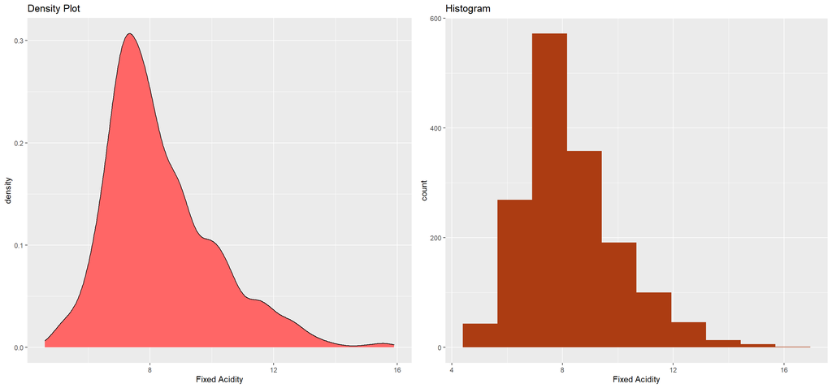

```r
plot_1 <- df%>%
  ggplot(aes(fixed.acidity)) +  geom_density(fill="#FF6666") + labs(x = "Fixed Acidity", title = "Density Plot")

plot_2 <- df%>%
  ggplot(aes(fixed.acidity))  + geom_histogram(bins = 10, fill = "#AC3C12")+ labs(x = "Fixed Acidity",title = "Histogram")

grid.arrange(plot_1, plot_2, ncol = 2)
```

The above are the plots showing the density of the data. Both the plot shows that there are lot many drinks with a fixed acidity level of 8. The graphs show that the data is skewed to the right. So let us calculate the skewness of the data.

```r
skewness(df$fixed.acidity)
```

```
## [1] 0.9818293
```

This means that the mean of the data is greater than the median of the data. We will use logarithmic transform or square root transformation to transform this distribution to the normal distribution.

### Now lets us see the distribution for volatile acidity

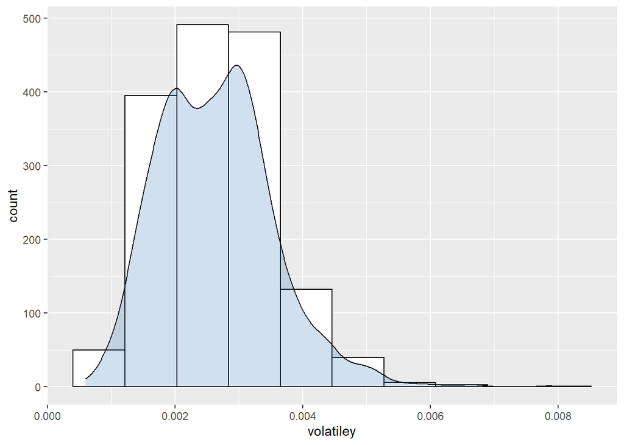

```r
df%>%
  ggplot(aes(volatile.acidity /200))  + geom_histogram(bins = 10, , colour="black", fill="white") +
  geom_density(fill="#1264AC", alpha = 0.2 ) +  labs(x = "volatiley")
```

```r
skewness(df$volatile.acidity)
```

```
## [1] 0.6709624
```

The skewness tells that the data is positively skewed. However, the volatile acidity is less skewed than fixed acidity.

### As we have 12 features in the data, let us use for loop to plot the data.

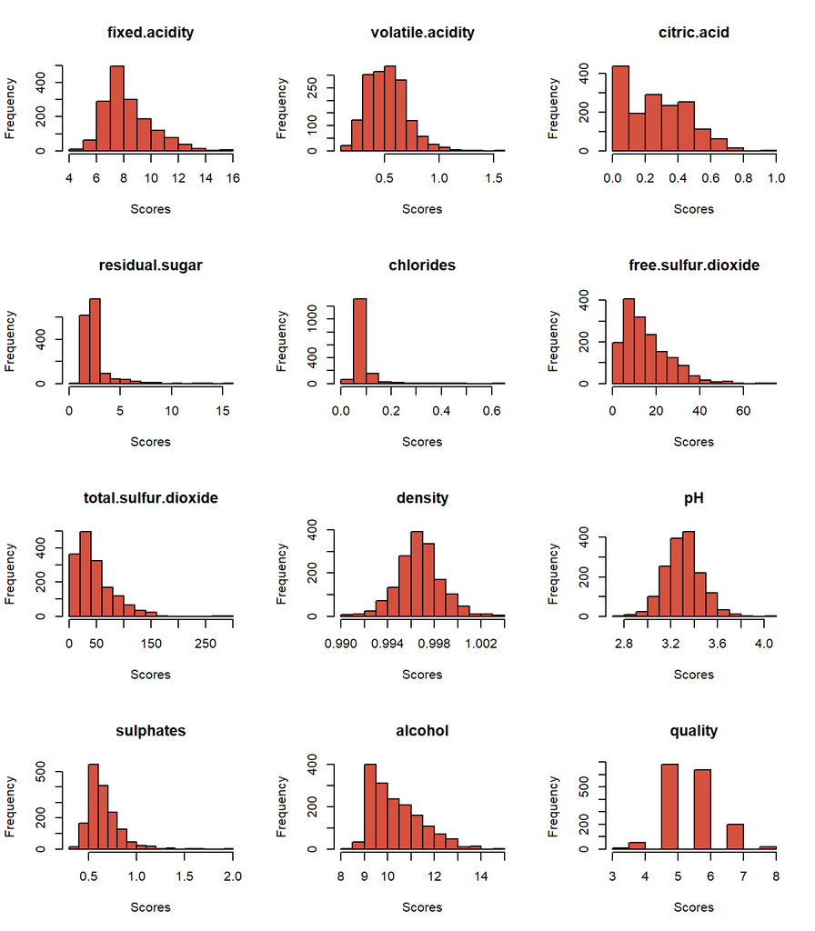

```r
par(mfrow = c(4, 3))


loop.vector <- 1:12

for (i in loop.vector) {

  x <- df[,i]

  hist(x,main = names(df)[i],xlab = "Scores" , col = "#D55241")
}
```

The graph above shows the histogram for every feature in the data. Almost all the parameters except density, ph looks skewed. It is assumed that if many samples are collected, the distribution curve of the data is very close to the bell curve. As we see some columns have right or left tail let us calculate the skewness of each feature.

### Calculating Skewness

We use the inbuilt skewness function to calculate skewness for each column. If the skewness is positive, the data is right-tailed, and if the skewness is negative, the data is left-tailed.

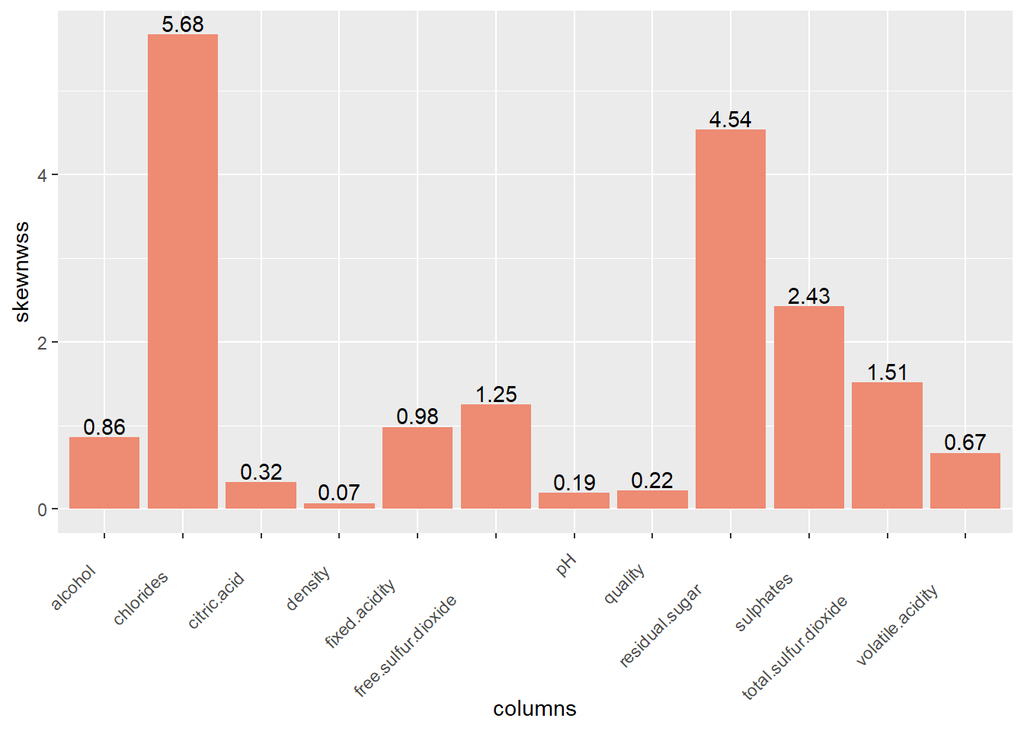

```r
skewnwss_df <- data.frame(skewnwss = skewness(df),columns = row.names(data.frame(skewness(df))))

ggplot(skewnwss_df, aes(x = columns, y = skewnwss)) + geom_bar(stat = "identity",position = "dodge",fill = '#EE8B73')+   geom_text(aes(label = round(skewnwss,2), vjust = -0.2)) + theme(axis.text.x = element_text(angle = 45, hjust = 1.5))
```

### Central tendency.

Now let us understand the central tendency of the data. Three methods used to understand the central tendency of the data are mean, median, and mode. Firstly, we plot the boxplots showing the median and Interquartile range for each feature in the data. The graph also marks outliers for each feature for each type of wine quality.

```r
df$quality <- factor(df$quality)
myplots <- vector('list', ncol(df))

for (i in 1:12){
  #message(i)
myplots[[i]] <- local({
  i <- i

  p1 <- ggplot(df, aes(x=quality, y=df[, i], color = quality)) +
    geom_boxplot(outlier.colour="red", outlier.shape=8,outlier.size=4) + labs(y = names(df[i]) )


 })
}
```

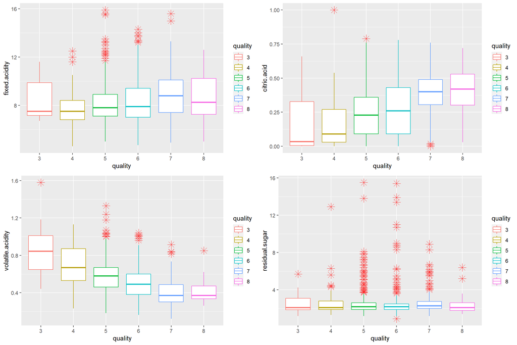

```r
source("http://peterhaschke.com/Code/multiplot.R")

multiplot(plotlist = myplots[1:4], cols = 2)
```

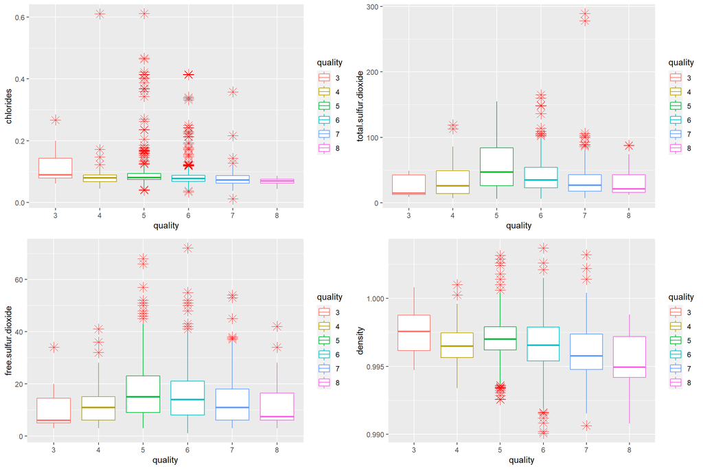

```r
multiplot(plotlist = myplots[5:8], cols = 2)
```

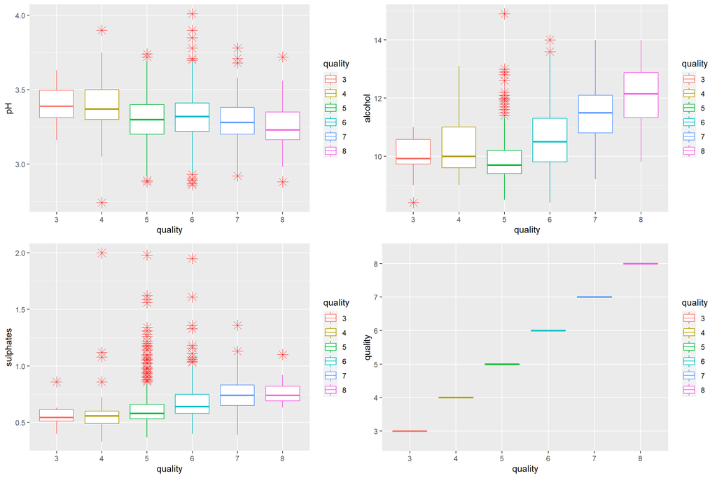

```r
multiplot(plotlist = myplots[9:12], cols = 2)
```

In some of the above graphs, a clear correlation can be seen between the median and quality of the wine. For instance, the median of volatile acidity can be seen dropping down as the quality of the wine improved. It even makes sense that the acidity gives a sour taste to the wine; this sour taste makes the taste of the wine unpleasant. Thus as the manufacture controls the level of volatile acids, the quality of wine improves.

The above graph also marks the outliers in the data. The point marked with ‘x’ are the outliers in the data. The standard rule of 1.5 IQR is used to mark the outliers.

Before performing any further analysis, let us take glims on the correlation within data.

### Correlation

```r
df$quality <- as.numeric(df$quality)
```

```
##
## Correlation method: 'pearson'
## Missing treated using: 'pairwise.complete.obs'
```

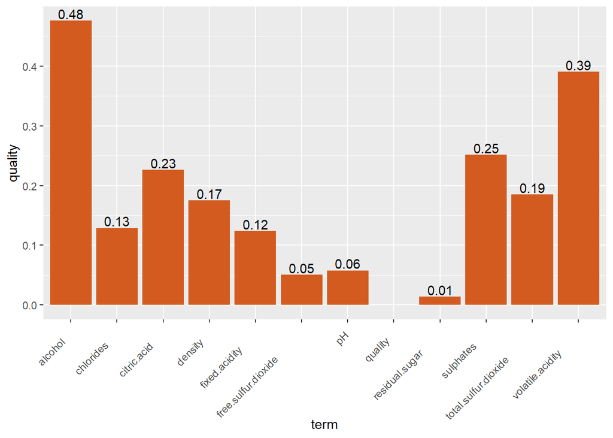

```r
df%>%
  correlate()%>%
  select(c("term", "quality"))%>%
  mutate(quality = abs(quality))%>%
  ggplot(aes(term, quality))+ geom_bar(stat = "identity",position = "dodge", fill = "#D35B20")+geom_text(aes(label = round(quality,2), vjust = -0.2))+ theme(axis.text.x = element_text(angle = 45, hjust = 1.5))
```

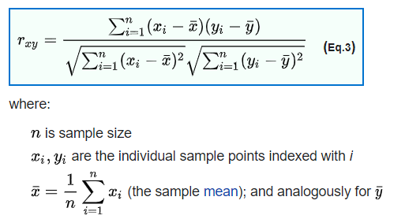

Source: Wikipedia image (“Pearson correlation coefficient,” 2021).

The above figure shows the formula to calculate Pearson correlation for a given sample. Although correlation is a good measure to understand the relationship between continuous variables, we perform it on all variables to get a general idea.

### Log transformation

Now, we perform log transformation to correct the skewness of the data. In this transformation, we take the log of every feature in the data.

```r
df_log <- data.frame(log (df[-c(3,12)]),df[c(3,12)])

df_log <- df_log %>%
  select(c("fixed.acidity","volatile.acidity","citric.acid","residual.sugar","chlorides","free.sulfur.dioxide","total.sulfur.dioxide",
           "density","pH","sulphates","alcohol","quality"))
```

### Plotting histogram

Once the log transformation is performed, we plot the histogram to see any change in the data distribution. The histogram is filled with green color so that it is easy to differentiate between the histogram of log features and non-log features.

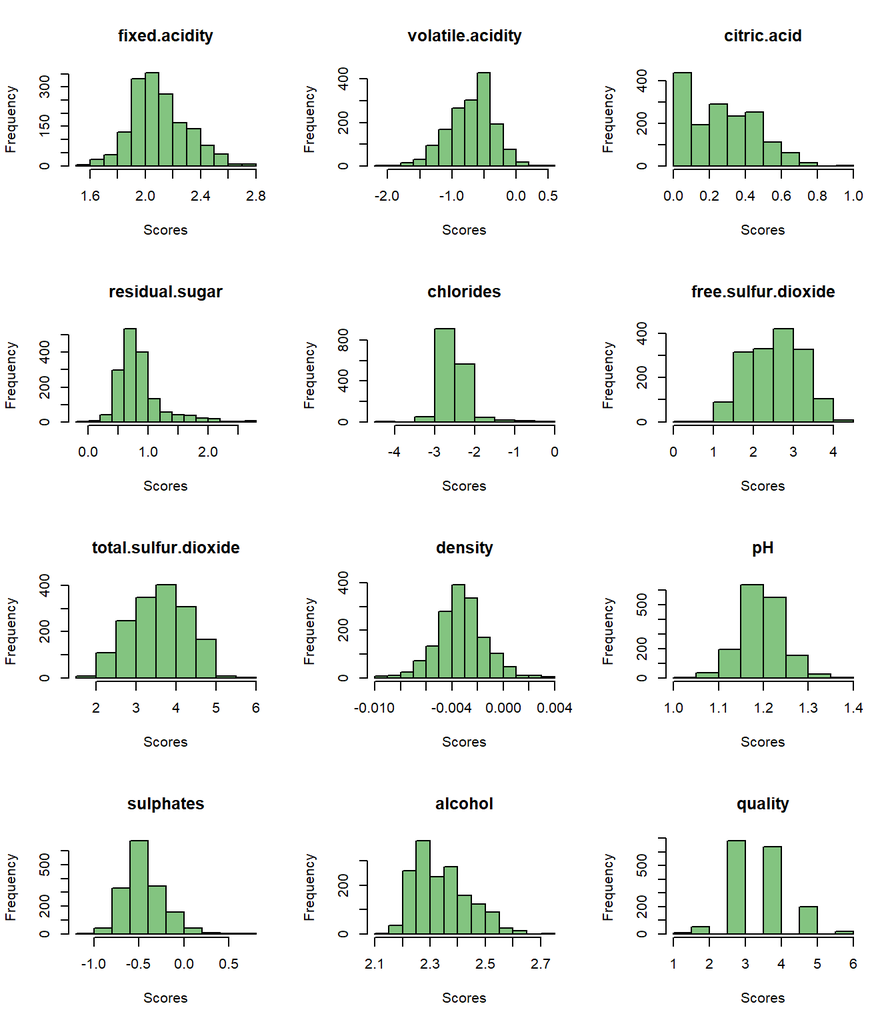

```r
par(mfrow = c(4, 3))


loop.vector <- 1:12

for (i in loop.vector) {

  x <- df_log[,i]

  hist(x,main = names(df_log)[i],xlab = "Scores", col = "#83C480" )
}
```

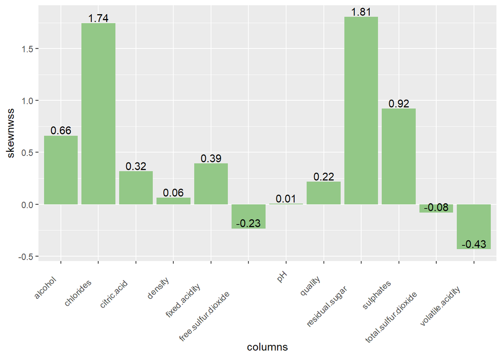

```r
skewnwss_df <- data.frame(skewnwss = skewness(df_log),columns = row.names(data.frame(skewness(df_log))))

ggplot(skewnwss_df, aes(x = columns, y = skewnwss)) + geom_bar(stat = "identity",position = "dodge",fill = '#93C887')+   geom_text(aes(label = round(skewnwss,2), vjust = -0.2)) + theme(axis.text.x = element_text(angle = 45, hjust = 1.5))
```

### Now let us plot and analyze the effect of performing log transform on the correlation of the data.

.

```
##
## Correlation method: 'pearson'
## Missing treated using: 'pairwise.complete.obs'
```

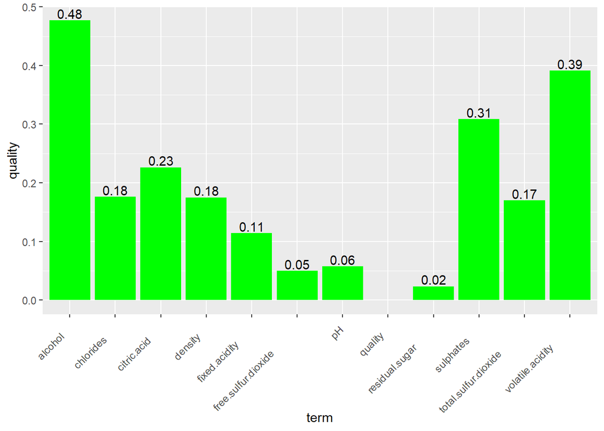

```r
df_log%>%
  correlate()%>%
  select(c("term", "quality"))%>%
  mutate(quality = abs(quality))%>%
  ggplot(aes(term, quality))+ geom_bar(stat = "identity",position = "dodge", fill = 'green')+geom_text(aes(label = round(quality,2), vjust = -0.2))+ theme(axis.text.x = element_text(angle = 45, hjust = 1.5))
```

The correlation of almost all the parameters after log transforming looks quite similar to the correlation before log transformation. The increase in correlation for few features can be seen; chlorides correlated 0.13 before transformation and 0.18 after transformation. A similar trend can be seen for sulfates and density.

### Checking if the data is balanced or not?.

To see this, we count the number of observations for each quantity.

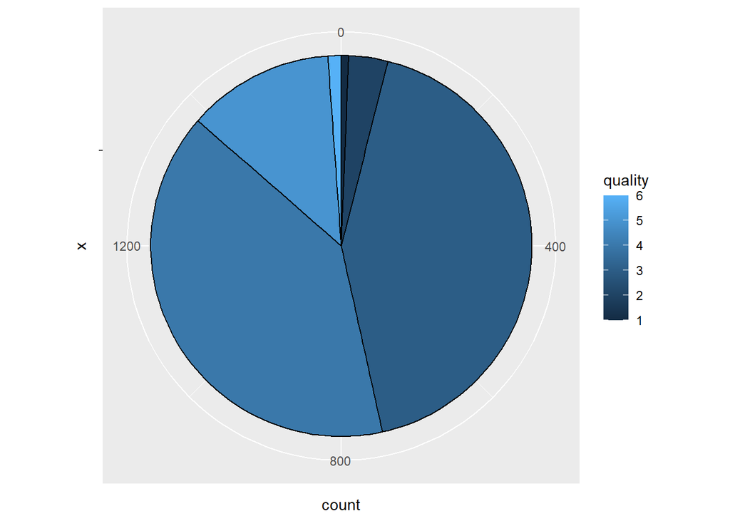

```r
df_log%>%
  group_by(quality)%>%
  summarise(count = n())%>%
  ggplot(aes(x= " ", fill = quality, y = count))  +geom_col(color = "black") +
  coord_polar("y", start=0)
```

We can see the data is highly imbalanced. If we train the model on this data, there stands a high probability that the trained model will be biased. We can solve this issue by randomly resampling the given data. The statistical term to perform this operation is called oversampling and undersampling.

## Balancing dataset

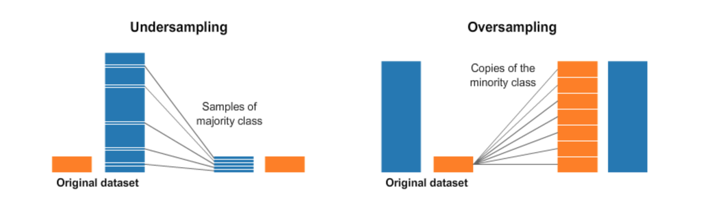

Source: (Badr, 2020).

The image above shows an illustration for over and undersampling.

- Undersampling: Removing random samples from classes with a large number of observations.
- Oversampling: Replicating random samples from the classes with less number of observations.

```r
set.seed(123)
library(ROSE)
df_log_1_2 <- df_log%>% filter((quality ==1)|(quality ==2))
df_log_1_2 <- ovun.sample(quality~., data = df_log_1_2, method = "both", N= 126*3 )$data

df_log_3_4 <- df_log%>% filter((quality ==3)|(quality ==4))
df_log_3_4 <- ovun.sample(quality~., data = df_log_3_4, method = "both", N= 126*3 )$data

df_log_5_6 <- df_log%>% filter((quality ==5)|(quality ==6))
df_log_5_6 <- ovun.sample(quality~., data = df_log_5_6, method = "both", N= 126*3 )$data

df_log <- rbind(df_log_1_2, df_log_3_4, df_log_5_6)
```

After performing over and undersampling, we once again plot the number of observations in each class.

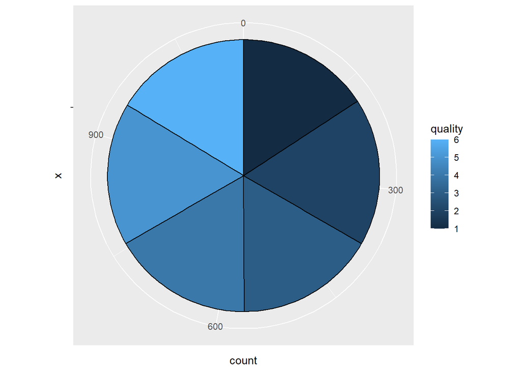

```r
df_log%>%
  group_by(quality)%>%
  summarise(count = n())%>%
  ggplot(aes(x= " ", fill = quality, y = count))  +geom_col(color = "black") +
  coord_polar("y", start=0)
```

The pie chart above shows us that all the classes are evenly distributed. This will thus stop the model from getting biased towards any particular class.

### Calculating mean and SD for all the features.

To understand more about the factors affecting the quality of wine, let us calculate each feature’s mean and standard deviation. Code chunks below first calculate the mean and standard deviation for each column. The calculated SD is then added and subtracted from the mean to understand the spread of data.

```r
df_log_mean <- df_log%>%
  group_by(quality)%>%
  summarise(across(c("fixed.acidity","volatile.acidity","citric.acid","residual.sugar","chlorides","free.sulfur.dioxide","total.sulfur.dioxide","density","pH","sulphates","alcohol"), mean, .names = "min___{.col}"))
df_log_sd <- df_log%>%
  group_by(quality)%>%
  summarise(across(c("fixed.acidity","volatile.acidity","citric.acid","residual.sugar","chlorides","free.sulfur.dioxide","total.sulfur.dioxide","density","pH","sulphates","alcohol"), sd))
df_log_m_s <-cbind(df_log_mean["quality"], df_log_mean[-c(1)] + df_log_sd[-c(1)])
names(df_log_m_s) <- c("quality","std_+_fixed.acidity","std_+_volatile.acidity","std_+_citric.acid","std_+_residual.sugar","std_+_chlorides","std_+_free.sulfur.dioxide","std_+_total.sulfur.dioxide","std_+_density","std_+_pH","std_+_sulphates","std_+_alcohol")

df_log_m_m_s <-cbind(df_log_mean["quality"], df_log_mean[-c(1)] - df_log_sd[-c(1)])
names(df_log_m_m_s) <- c("quality","std_-_fixed.acidity","std_-_volatile.acidity","std_-_citric.acid","std_-_residual.sugar","std_-_chlorides","std_-_free.sulfur.dioxide","std_-_total.sulfur.dioxide","std_-_density","std_-_pH","std_-_sulphates","std_-_alcohol")
```

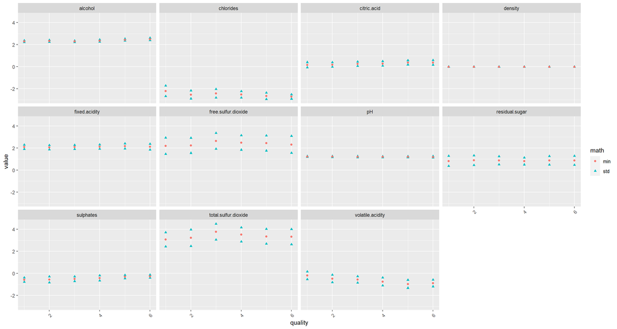

```r
inner_join(inner_join(df_log_m_s, df_log_m_m_s, by = "quality"),df_log_mean, by = "quality" )%>%
  melt(id = c("quality"))%>%
  mutate(math = substr(variable,1,3))%>%
  mutate(variable = substr(variable,7,100))%>%
  ggplot(aes(x= quality, y = value)) + geom_point(aes(shape = math, color = math) ) + facet_wrap(~variable, ncol = 4)+ theme(axis.text.x = element_text(angle = 45, hjust = 1))
```

Now let us perform a T-test and ANOVA on features that have less correlation.

## Hypothesis testing.

To understand what features are essential to predict the quality of wine, we performed a Pearson correlation. However, few features have a very low correlation. Thus we perform a T-test on fixed acidity and ANOVA on residual sugar, PH, and free SO2. As the values in fixed acidity have continuous values, thus we perform a T-test on this column.

Performing T-test and ANOVA on features that have less correlation. As the values in fixed acidity have continuous values, thus we perform T-test on this column. We perform this hypothesis testing to know if these variables affect the dependent variable or not.

```r
fixed_acidity_upper <- df_log%>%
  select(c("fixed.acidity", "quality"))%>%
  filter(quality >3)

fixed_acidity_lowe <- df_log%>%
  select(c("fixed.acidity", "quality"))%>%
  filter(quality <= 10)
```

### Hypothesis testing for fixed.acidity

```r
t.test(fixed_acidity_upper$fixed.acidity,df_log$fixed.acidity,  mu =0, alternative = "greater", conf.level = 0.95)
```

```
##
##  Welch Two Sample t-test
##
## data:  fixed_acidity_upper$fixed.acidity and df_log$fixed.acidity
## t = 2.1363, df = 1053.3, p-value = 0.01644
## alternative hypothesis: true difference in means is greater than 0
## 95 percent confidence interval:
##  0.005789669         Inf
## sample estimates:
## mean of x mean of y
##  2.128226  2.102983
```

P-Value is less than alpha so we reject null hypothesis.Thus, it can be said that this parameter affects the dependent feature.

Now, let us perform ANOVA on residual sugar, PH, and free SO2 and understand whether these features affect wine quality.

### ANOVA for Residual sugar

- H0: Residual sugar has no relation with the quality of the wine.
- H1: Residual sugar has relation with the quality of the wine.

```r
df_anove <- df_log[c("residual.sugar", "quality")]
df_anove$quality <- factor(df_anove$quality)
Anova_results <- aov (residual.sugar ~ quality, data = df_anove)
```

```r
summary(Anova_results)
```

```
##               Df Sum Sq Mean Sq F value Pr(>F)
## quality        5   0.87  0.1748   1.114  0.351
## Residuals   1128 177.07  0.1570
```

For a confidence interval of 95%, the alpha value is 0.05, and the p-value we got in this test is 0.351; thus, we fail to reject our null hypothesis.

### Performing Anova for pH

- H0: pH has no relation with the quality of the wine.
- H1: pH has relation with the quality of the wine.

```r
df_anove <- df_log[c("pH", "quality")]
df_anove$quality <- factor(df_anove$quality)
Anova_results <- aov (pH ~ quality, data = df_anove)
```

```r
summary(Anova_results)
```

```
##               Df Sum Sq Mean Sq F value   Pr(>F)
## quality        5 0.1632 0.03263    13.1 2.04e-12 ***
## Residuals   1128 2.8102 0.00249
## ---
## Signif. codes:  0 '***' 0.001 '**' 0.01 '*' 0.05 '.' 0.1 ' ' 1
```

For a confidence interval of 95%, the alpha value is 0.05, and the p-value we got in this test is significantly less than 0.05; thus, we reject our null hypothesis.

### Performing ANOVA for free SO2

H0: Free SO2 has no relation with the quality of the wine. H1: Free SO2 has relation with the quality of the wine.

```r
df_anove <- df_log[c("free.sulfur.dioxide", "quality")]
df_anove$quality <- factor(df_anove$quality)
Anova_results <- aov (free.sulfur.dioxide ~ quality, data = df_anove)
```

```r
summary(Anova_results)
```

```
##               Df Sum Sq Mean Sq F value   Pr(>F)
## quality        5   27.1   5.421    10.8 3.64e-10 ***
## Residuals   1128  566.0   0.502
## ---
## Signif. codes:  0 '***' 0.001 '**' 0.01 '*' 0.05 '.' 0.1 ' ' 1
```

For a confidence interval of 95%, the alpha value is 0.05, and the p-value we got in this test is significantly less than 0.05; thus, we reject our null hypothesis.

## Training Model

### Train and test split

The size of our training set is 80% of the total dataset, and the rest is our testing set.

```r
df_log$quality <- factor(df_log$quality)
df_log <- df_log[c("fixed.acidity","volatile.acidity","citric.acid","chlorides","free.sulfur.dioxide","total.sulfur.dioxide","density","pH","sulphates","alcohol", "quality")]
names(df_log) <- str_replace(names(df_log), "[.]", "_")
```

```r
library(caTools)
set.seed(123)


split = sample.split(df_log$quality, SplitRatio = 0.8)
training_set = subset(df_log, split == TRUE)
test_set = subset(df_log, split == FALSE)
```

As we performed all the essential operations on the data, it is now ready to feed to the model. We use multinomial logistic regression as a classifier to train our data.

### multinomial logistic regression

```r
library(nnet)
mymodel <- multinom(quality~fixed_acidity + volatile_acidity + citric_acid + chlorides + free_sulfur.dioxide + total_sulfur.dioxide + density + pH + sulphates + alcohol, data = training_set)
summary(mymodel)
```

```
## Call:
## multinom(formula = quality ~ fixed_acidity + volatile_acidity +
##     citric_acid + chlorides + free_sulfur.dioxide + total_sulfur.dioxide +
##     density + pH + sulphates + alcohol, data = training_set)
##
## Coefficients:
##   (Intercept) fixed_acidity volatile_acidity citric_acid chlorides
## 2  -11.772179     -4.531187        -5.595022   -1.594739 -1.982014
## 3    7.793156     -7.535897        -6.196449   -2.095354 -1.229528
## 4  -20.953642     -4.604117        -7.710845   -4.197119 -1.873708
## 5  -54.319322     -2.984212        -8.499676   -4.060689 -4.018131
## 6  -43.468478     -5.736174        -7.209785   -1.947679 -5.255865
##   free_sulfur.dioxide total_sulfur.dioxide    density        pH  sulphates
## 2          -1.6775435             1.915308 -231.76342 -18.33409 -1.5419087
## 3          -1.7901754             3.036894   87.19259 -25.67856 -0.6910129
## 4          -1.6038858             2.603029  -31.66875 -25.99426  1.0788299
## 5          -1.0190438             1.667227   95.61386 -24.53758  5.1548784
## 6          -0.9925958             1.096234  -54.24063 -49.07659  7.1630892
##    alcohol
## 2 14.56766
## 3 12.37085
## 4 22.09259
## 5 32.77473
## 6 42.07613
##
## Std. Errors:
##   (Intercept) fixed_acidity volatile_acidity citric_acid chlorides
## 2    9.209609      1.478780        0.8196899    1.355817 0.4172162
## 3    9.149595      1.477582        0.8376553    1.345029 0.3928597
## 4    9.350057      1.511146        0.8737463    1.493269 0.4890225
## 5   10.910797      1.732272        0.9508003    1.773805 0.6807813
## 6   11.867212      1.880523        1.0068740    1.951136 0.7431492
##   free_sulfur.dioxide total_sulfur.dioxide  density       pH sulphates  alcohol
## 2           0.4825183            0.5442269 82.54047 5.250658 0.8887544 2.991239
## 3           0.4804422            0.5493722 77.81121 5.181701 0.8338132 3.090340
## 4           0.5009892            0.5699880 81.74432 5.404463 0.8806349 3.161245
## 5           0.5574330            0.6285539 83.81874 6.163575 1.0400114 3.438109
## 6           0.5970006            0.6763578 55.89928 7.112356 1.1808212 3.700903
##
## Residual Deviance: 2016.867
## AIC: 2126.867
```

```r
pred <- predict(mymodel, training_set)
table(pred, training_set$quality)
```

```
##
## pred   1   2   3   4   5   6
##    1 113  26  18   6   2   0
##    2  12  69  31  29   6   0
##    3  18  28  72  27   5   0
##    4   0  31  23  50  24   0
##    5   0   0   6  29  64  33
##    6   0   5   0  11  53 115
```

```r
accuracy(training_set$quality, pred)
```

```
## [1] 0.5331126
```

The accuracy is relatively low using this model. Thus; we try training the data using a different model for better accuracy.

### Training data on Random Forest Classifier.

```r
library(randomForest)
rfm <- randomForest(quality~., training_set, ntrees = 200 )
```

Predicting the quality of wine using the test dataset. After predicting the output on the test dataset, we calculate the confusion matrix and accuracy.

```r
pred <- predict(rfm, test_set)
table(pred, test_set$quality)
```

```
##
## pred  1  2  3  4  5  6
##    1 36  0  0  1  0  0
##    2  0 37  4  3  0  0
##    3  0  0 29  9  1  0
##    4  0  3  4 18  7  0
##    5  0  0  1  7 31  0
##    6  0  0  0  0  0 37
```

```r
accuracy(test_set$quality, pred)
```

```
## [1] 0.8245614
```

The Accuracy achieved from the random forest classifier is 82%. Thus we can use this model to predict the quality of the wine.

The chunk of code given below is used to visualize our predictions and give us a better understanding on the performance of our engine.

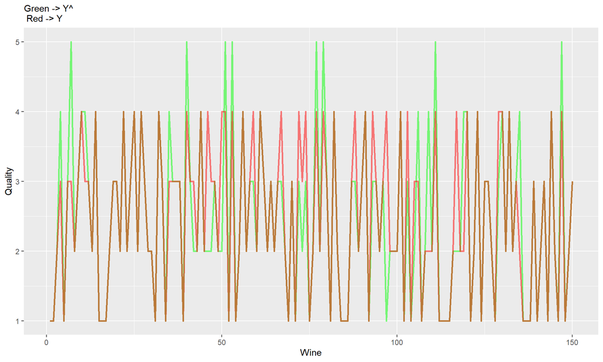

```r
rows <- sample(150)
ggplot()+geom_line(aes(c(1:150),as.integer(tail(pred[rows],150))), colour ="green", size =1, alpha =0.5) +labs(subtitle = "Green -> Y^ \n Red -> Y") + geom_line(aes(c(1:150), as.integer(tail(test_set$quality[rows], 150))), color = "red", size =1, alpha =0.5)+  xlab("Wine") +ylab("Quality")  +labs(color = "Y")
```

## Conclusion

Thus we have extracted essential features from the data. The features in the captured data were skewed and not close to normal distribution. This study performed log transformation on the data to reduce the skewness in the data. While taking care of skewness in the data, we ensured that the relation between dependent and independent variables was not affected. For the features with less correlation we performed T-test and ANOVA to verify if these features affect the quality of the wine.

Excellent grade of wine has following qualities controlled level of aroma due to Volatile acids, Citrus fresh due to citrus acids, a less salty taste which is added by chlorides in grapes, less density, slightly purple hue due to its pH scale, slightly high level of sulfates and higher alcohol levels.

Once the most important features were extracted from the data, the imbalance in the dataset was taken care of by performing oversampling and undersampling. Finally, after all the essential operations on the data random forest classifier was trained on the data, which exhibited an accuracy score above 80%. Thus we can use the method proposed by the study to predict the quality to overcome existing issues in wine tasting.

This study can be extended further to improve the accuracy of the model. Using more sophisticated classifiers and hyperparameter tuning can be used to achieve desired results.

## One Drive link

The following files have been uploaded to OneDive folder:

- rmd file.
- PPT.
- Report.
- Dataset.
- Presentation video.

Link: https://instituteoftechnol663-my.sharepoint.com/:f:/g/personal/c00265741_itcarlow_ie/EiR4loHfK5JJjrRRa6p4jiYBL0G4TXBULN36ZxpCOHbzCg?e=qWSJsT

## References

Coli, M.S., Rangel, A.G.P., Souza, E.S., Oliveira, M.F., Chiaradia, A.C.N., Coli, M.S., Rangel, A.G.P., Souza, E.S., Oliveira, M.F., Chiaradia, A.C.N., 2015. Food Science and Technology 35, 95–99.

Cortez, P., Cerdeira, A., Almeida, F., Matos, T., Reis, J., 2009. Decision Support Systems, Smart Business Networks** : Concepts and Empirical Evidence 47, 547–553.

Badr, W., 2020. Having an Imbalanced Dataset? Here Is How You Can Fix It. [WWW Document]. Medium. URL https://towardsdatascience.com/having-an-imbalanced-dataset-here-is-how-you-can-solve-it-1640568947eb (accessed 5.14.21).

Coli, M.S., Rangel, A.G.P., Souza, E.S., Oliveira, M.F., Chiaradia, A.C.N., Coli, M.S., Rangel, A.G.P., Souza, E.S., Oliveira, M.F., Chiaradia, A.C.N., 2015. Food Science and Technology 35, 95–99.

Pearson correlation coefficient, 2021. . Wikipedia.

CVRVV, n.d. Vinho Verde [WWW Document]. URL https** ://www.vinhoverde.pt (accessed 5.10.21). Hakim, S., 2018. Citric Acid [WWW Document]. Viticulture and Enology. URL https** ://wineserver.ucdavis.edu/industry-info/enology/methods-and-techniques/common-chemical-reagents/citric-acid (accessed 5.11.21).

Hale, N., 2019. What is Acidity in Wine? [WWW Document]. Wine Enthusiast. URL https** ://www.winemag.com/2019/06/19/what-is-acidity-in-wine/ (accessed 5.11.21).

Lemieux, P., 2019. Everything There is to Know about Residual Sugar in Wine [WWW Document]. Alfred l’Expert en Vin. URL https** ://alfredsommelier.com/en/everything-there-is-to-know-about-residual-sugar-in-wine/ (accessed 5.11.21).

Slinkard, S., n.d. Are Wine Sulfites to Blame for Your Post-Wine Hangovers? [WWW Document]. The Spruce Eats. URL https** ://www.thespruceeats.com/what-are-wine-sulfites-3511277 (accessed 5.11.21).

Understanding Sulfur Levels in Wine [WWW Document], 2017. . WineShop At Home. URL https** ://www.wineshopathome.com/understanding-sulfur-levels-wine/ (accessed 5.11.21).

Whats in Wine? | Waterhouse Lab [WWW Document], n.d. URL https** ://waterhouse.ucdavis.edu/whats-in-wine (accessed 5.10.21).

White, N.A., 2019a. Fixed Acidity [WWW Document]. Waterhouse Lab. URL https** ://waterhouse.ucdavis.edu/whats-in-wine/fixed-acidity (accessed 5.10.21).

White, N.A., 2019b. Volatile Acidity [WWW Document]. Waterhouse Lab. URL https** ://waterhouse.ucdavis.edu/whats-in-wine/volatile-acidity (accessed 5.10.21).

White, N.A., 2019c. Higher Alcohols [WWW Document]. Waterhouse Lab. URL https** ://waterhouse.ucdavis.edu/whats-in-wine/higher-alcohols (accessed 5.11.21). Wine, 2021. . Wikipedia.